# DATA 607 Final Project

2022-11-23

## Motivation

- **Research Question**: Do environmental factors (like air quality) impact a student’s academic performance?

## Datasources

- [AQ Air Quality Public REST API](https://docs.openaq.org/reference/introduction-1)
- [Open Weather Map API](https://openweathermap.org/api)
- [NYC Open Data Education files on test results](https://data.cityofnewyork.us/browse?category=Education&q=Test&sortBy=relevance) : while not a perfect indicator of academic performance, these do give some insight into the academic progress of students in different areas of the city.

## Academic Performance Data

- [Dataset from NYC Open Data](https://data.cityofnewyork.us/Education/2006-2012-Math-Test-Results-All-Students/3mrr-8h5c/data) (csv) – test results by student.
- Can use District Borough Number (DBN) to lookup geographic locations and compare against AQ data

```r
dbn_url <- "https://raw.githubusercontent.com/andrewbowen19/cunyDATA607/main/projects/final_project/2006_-_2012__Math_Test_Results__-_All_Students.csv"

tests <- read.csv(dbn_url)

head(tests)
```

```
##      DBN Grade Year  Demographic Number.Tested Mean.Scale.Score Num.Level.1
## 1 01M015     3 2006 All Students            39              667           2
## 2 01M015     3 2007 All Students            31              672           2
## 3 01M015     3 2008 All Students            37              668           0
## 4 01M015     3 2009 All Students            33              668           0
## 5 01M015     3 2010 All Students            26              677           6
## 6 01M015     3 2011 All Students            28              671          10
##   Pct.Level.1 Num.Level.2 Pct.Level.2 Num.Level.3 Pct.Level.3 Num.Level.4
## 1         5.1          11        28.2          20        51.3           6
## 2         6.5           3         9.7          22          71           4
## 3           0           6        16.2          29        78.4           2
## 4           0           4        12.1          28        84.8           1
## 5        23.1          12        46.2           6        23.1           2
## 6        35.7          13        46.4           5        17.9           0
##   Pct.Level.4 Num.Level.3.and.4 Pct.Level.3.and.4
## 1        15.4                26              66.7
## 2        12.9                26              83.9
## 3         5.4                31              83.8
## 4           3                29              87.9
## 5         7.7                 8              30.8
## 6           0                 5              17.9
```

## Getting School Geospatial Data

Looking up [school district GIS data from NYC Open Data](https://data.cityofnewyork.us/Education/School-Districts/r8nu-ymqj). School point locations can be found [here](https://data.cityofnewyork.us/Education/School-Point-Locations/jfju-ynrr), we’ll download them and unzip the file to get the shp file

## Cleaning School Location Data

## Joining & Cleaning Academic Data

Let’s join our `school_locs` dataframe to our `tests`

## Pulling Air Quality Data for New York City

Looking up air quality for school locations in [New York’s geographical area](https://www.latlong.net/place/new-york-city-ny-usa-1848.html).

## Air quality data

Using this [NYC Open Data Air Quality Dataset from their API](https://data.cityofnewyork.us/Environment/Air-Quality/c3uy-2p5r). Going to call their API

Breaking down air quality data by borough. Air pollution [varies borough-to-borough in New York City](https://vega.github.io/schema/vega-lite/v4.json) so we’ll group our data that way. We’ll need to add a `borough` column to our Air quality dataset

```
##   unique_id indicator_id                 name measure measure_info
## 1    216498          386           Ozone (O3)    Mean          ppb
## 2    216499          386           Ozone (O3)    Mean          ppb
## 3    219969          386           Ozone (O3)    Mean          ppb
## 4    219970          386           Ozone (O3)    Mean          ppb
## 5    164876          383 Sulfur Dioxide (SO2)    Mean          ppb
## 6    164877          383 Sulfur Dioxide (SO2)    Mean          ppb
##   geo_type_name geo_join_id                       geo_place_name    time_period
## 1            CD         313                  Coney Island (CD13)    Summer 2013
## 2            CD         313                  Coney Island (CD13)    Summer 2014
## 3       Borough           1                                Bronx    Summer 2013
## 4       Borough           1                                Bronx    Summer 2014
## 5            CD         211     Morris Park and Bronxdale (CD11) Winter 2008-09
## 6            CD         212 Williamsbridge and Baychester (CD12) Winter 2008-09
##                start_date data_value borough_code year   borough
## 1 2013-06-01T00:00:00.000      34.64            3 2013 Manhattan
## 2 2014-06-01T00:00:00.000      33.22            3 2014 Manhattan
## 3 2013-06-01T00:00:00.000      31.25            1 2013     Bronx
## 4 2014-06-01T00:00:00.000      31.15            1 2014     Bronx
## 5 2008-12-01T00:00:00.000       5.89            2 2008  Brooklyn
## 6 2008-12-01T00:00:00.000       5.75            2 2008  Brooklyn
```

## Additional AQ Data Cleaning

## Joining our Air Quality and Academic

## Data Analysis

Let’s get a sense of the distributions for our `ozone` and `sulfer_o2` variables

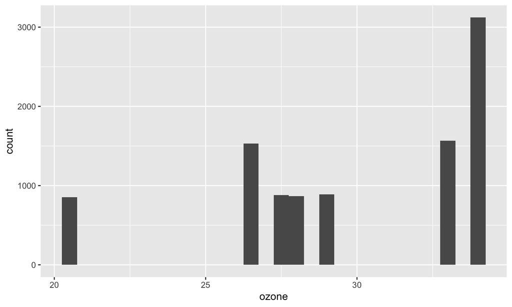

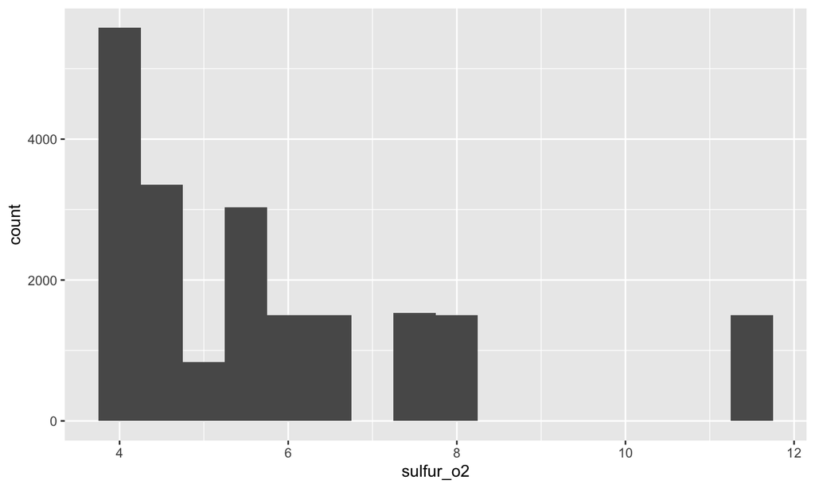

Running an Analysis of Variance (ANOVA) hypothesis test to see if there’s a statistically significant different in ozone levels between boroughs.We’ll conduct this test with significance level (\(\alpha = 0.05\)) and the following hypotheses:

- \(H_0\): There is **no** difference in mean ozone (O3) levels between NYC boroughs
- \(H_a\): There **is a** difference in mean ozone (O3) levels between NYC boroughs

```
##               Df Sum Sq Mean Sq F value Pr(>F)
## borough        1  67576   67576    6310 <2e-16 ***
## Residuals   9710 103984      11
## ---
## Signif. codes:  0 '***' 0.001 '**' 0.01 '*' 0.05 '.' 0.1 ' ' 1
## 297691 observations deleted due to missingness
```

## ANOVA (SO2)

- \(H_0\): There is **no** difference in mean sulfur dioxide (SO2) levels between NYC boroughs
- \(H_a\): There **is a** difference in mean sulfur dioxide (SO2) levels between NYC boroughs

```
##                Df Sum Sq Mean Sq F value Pr(>F)
## borough         1  22844   22844    6608 <2e-16 ***
## Residuals   20329  70277       3
## ---
## Signif. codes:  0 '***' 0.001 '**' 0.01 '*' 0.05 '.' 0.1 ' ' 1
## 287072 observations deleted due to missingness
```

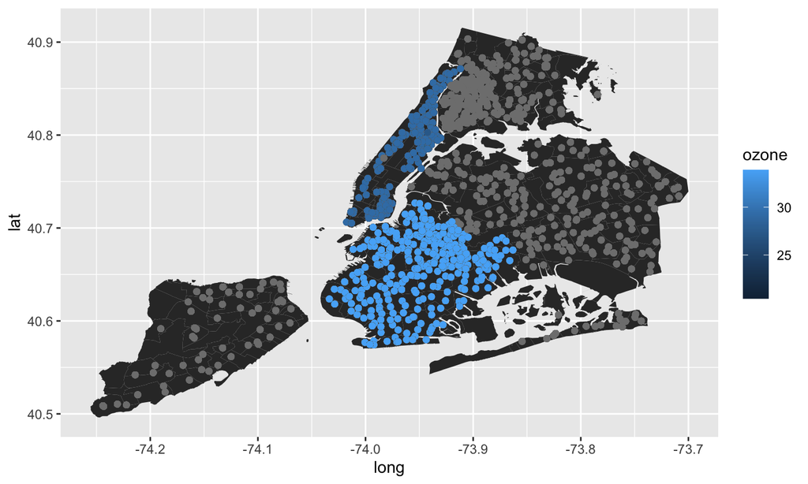

[figure not shown]